# Kmeans, Kmedoid Clustering 資料分群

賴冠維

2020/11/10

```r
library(dplyr)
library(magrittr) #pipelines
library(tidyverse)  # data manipulation
library(cluster)    # clustering algorithms
library(factoextra) # clustering algorithms & visualization
```

#### 資料預處理:

(1)遺失值處理  
(2)資料標準化

- USArrests是根據1973年，美國50州各州，平均每100,000個居民裡， 因為犯下Murder(謀殺)、Assault(襲擊他人)、與Rape(強暴)而遭逮補的人數，UrbanPop代表各州居住在都會區的人口百分比。

```r
inputData <-
  USArrests %>%
  na.omit() %>% # 忽略遺失值
  scale() # 資料標準化
```

get_dist() 預設歐式距離

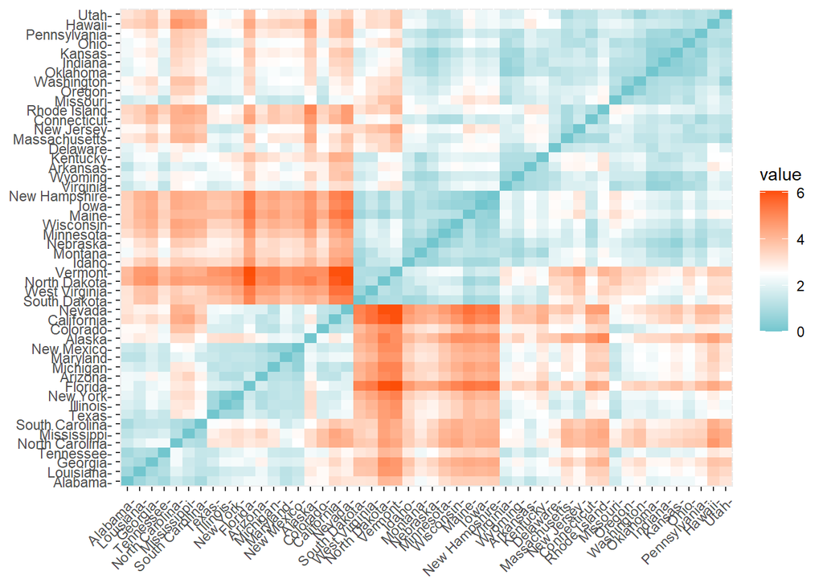

```r
distance <- get_dist(x = inputData)
fviz_dist(dist.obj = distance,
          gradient = list(low = "#00AFBB", mid = "white", high = "#FC4E07"))
```

##### Kmeans 步驟

一般是以沒有任何物件變換所屬集群為停止絛件(代表分群結果已經穩定不變)，也就是所謂的$square-error\ criterion$(減小每個群聚中，每一點與群中心的距離平方誤差)：
$$E = \Sigma^K_{i=1}\Sigma_{p\in{C_i}}|p-m_i|^2$$
$m_i$表集群i的中心
$p$是集群i內的物件
$C_i$則代表集群i

```r
set.seed(101)
k_clust <- kmeans(inputData, centers = 2, nstart = 25)
str(k_clust)
```

```
## List of 9
##  $ cluster     : Named int [1:50] 1 1 1 2 1 1 2 2 1 1 ...
##   ..- attr(*, "names")= chr [1:50] "Alabama" "Alaska" "Arizona" "Arkansas" ...
##  $ centers     : num [1:2, 1:4] 1.005 -0.67 1.014 -0.676 0.198 ...
##   ..- attr(*, "dimnames")=List of 2
##   .. ..$ : chr [1:2] "1" "2"
##   .. ..$ : chr [1:4] "Murder" "Assault" "UrbanPop" "Rape"
##  $ totss       : num 196
##  $ withinss    : num [1:2] 46.7 56.1
##  $ tot.withinss: num 103
##  $ betweenss   : num 93.1
##  $ size        : int [1:2] 20 30
##  $ iter        : int 1
##  $ ifault      : int 0
##  - attr(*, "class")= chr "kmeans"
```

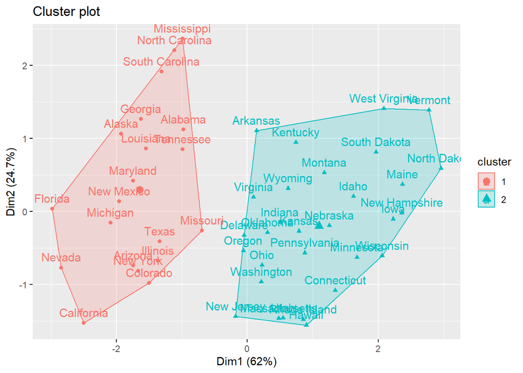

```r
fviz_cluster(k_clust, data = inputData)
```

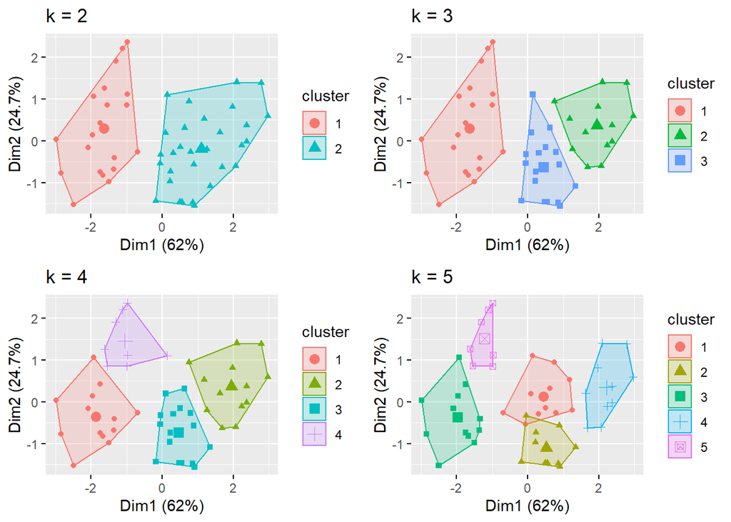

```r
# 嘗試多種k的分群效果
set.seed(101)
k_clust <- kmeans(inputData, centers = 2, nstart = 25)
k_clust_3 <- kmeans(inputData, centers = 3, nstart = 25)
k_clust_4 <- kmeans(inputData, centers = 4, nstart = 25)
k_clust_5 <- kmeans(inputData, centers = 5, nstart = 25)


# plots to compare
p1 <- fviz_cluster(k_clust, geom = "point", data = inputData) + ggtitle("k = 2")
p2 <- fviz_cluster(k_clust_3, geom = "point",  data = inputData) + ggtitle("k = 3")
p3 <- fviz_cluster(k_clust_4, geom = "point",  data = inputData) + ggtitle("k = 4")
p4 <- fviz_cluster(k_clust_5, geom = "point",  data = inputData) + ggtitle("k = 5")

library(gridExtra)
grid.arrange(p1, p2, p3, p4, nrow = 2) # Arrange multiple grobs on a page (將不會影響到par()中參數設定)
```